# Supervised Learning : Exploring Robust Logistic Regression Models for Handling Quasi-Complete Separation

John Pauline Pineda

February 19, 2023

# **1. Table of Contents**

This project explores different robust alternatives for handling quasi-complete separation during logistic regression modelling using various helpful packages in **R**. Methods applied in the analysis to evaluate a quasi-complete condition when a covariate almost perfectly predicts the outcome included the **Firth’s Bias-Reduced Logistic Regression**, **Firth’s Logistic Regression With Added Covariate**, **Firth’s Logistic Regression With Intercept Correction**, **Bayesian Generalized Linear Model With Cauchy Priors** and **Ridge-Penalized Logistic Regression** algorithms. The resulting predictions derived from the candidate models were evaluated in terms of the stability of their coefficient estimates and standard errors, including the validity of their logistic profiles and the distribution of their predicted points, which were all compared to that of the baseline model without any form of quasi-complete separation treatment. All results were consolidated in a **Summary** presented at the end of the document.  
Quasi-complete or complete separation is a monotone likelihood phenomenon observed in the fitting process of a logistic regression model when the likelihood converges while at least one parameter estimate diverges to positive or negative infinity. The algorithms applied in this study (mostly contained in the **logistf** and **arm** packages) attempt to reduce the bias of the maximum likelihood estimates through penalization, producing finite parameter estimates in the process.

## 1.1 Sample Data

The **sex2** dataset from the **logistf** package was used for this illustrated example. One of the original categorical predictors was transformed to better simulate a quasi-complete condition when a covariate almost perfectly predicts the outcome.  
Preliminary dataset assessment:  
**[A]** 239 rows (observations)  
**[A.1]** Train Set = 239 observations  
**[B]** 7 columns (variables)  
**[B.1]** 1/7 response = UTI variable (factor)  
**[B.1.1]** Levels = UTI=No < UTI=Yes  
**[B.2]** 6/7 predictors = All remaining variables (6/6 factor)

**Code Chunk | Output**

```r
##################################
# Loading R libraries
##################################
library(AppliedPredictiveModeling)
library(caret)
library(rpart)
library(lattice)
library(dplyr)
library(tidyr)
library(moments)
library(skimr)
library(RANN)
library(pls)
library(corrplot)
library(tidyverse)
library(lares)
library(DMwR)
library(gridExtra)
library(rattle)
library(rpart.plot)
library(RColorBrewer)
library(stats)
library(nnet)
library(elasticnet)
library(earth)
library(party)
library(kernlab)
library(randomForest)
library(Cubist)
library(pROC)
library(mda)
library(klaR)
library(pamr)
library(OptimalCutpoints)
library(broom)
library(PRROC)
library(ggpubr)
library(Hmisc)
library(logistf)
library(arm)
library(glmnet)

##################################
# Loading source and
# formulating the train set
##################################
data(sex2)
sex2$dia <- sex2$case
sex2$dia[1] <- 0
UTI_Train <- as.data.frame(sex2)

##################################
# Applying verbose descriptions
# for the response and predictor variables
##################################
colnames(UTI_Train) <- c("UTI",
                         "Age_24",
                         "Contraceptive",
                         "Condom",
                         "LubricatedCondom",
                         "Spermicide",
                         "Diaphragm")

UTI <- UTI_Train

UTI_Train <- lapply(UTI_Train, function(x) ifelse(x==1,"Yes","No"))
UTI_Train <- lapply(UTI_Train, function(x) as.factor(as.character(x)))
UTI_Train <- as.data.frame(UTI_Train)

##################################
# Performing a general exploration of the train set
##################################
dim(UTI_Train)
```

```
## [1] 239   7
```

```r
str(UTI_Train)
```

```
## 'data.frame':    239 obs. of  7 variables:
##  $ UTI             : Factor w/ 2 levels "No","Yes": 2 2 2 2 2 2 2 2 2 2 ...
##  $ Age_24          : Factor w/ 2 levels "No","Yes": 1 1 1 1 1 1 1 1 1 1 ...
##  $ Contraceptive   : Factor w/ 2 levels "No","Yes": 1 1 1 1 1 1 1 1 1 1 ...
##  $ Condom          : Factor w/ 2 levels "No","Yes": 1 2 2 2 2 2 2 2 2 2 ...
##  $ LubricatedCondom: Factor w/ 2 levels "No","Yes": 1 1 1 1 1 1 1 1 1 1 ...
##  $ Spermicide      : Factor w/ 2 levels "No","Yes": 2 1 1 1 1 1 1 1 1 1 ...
##  $ Diaphragm       : Factor w/ 2 levels "No","Yes": 1 2 2 2 2 2 2 2 2 2 ...
```

```r
summary(UTI_Train)
```

```
##   UTI      Age_24    Contraceptive Condom    LubricatedCondom Spermicide
##  No :109   No :201   No : 83       No :112   No :159          No :180
##  Yes:130   Yes: 38   Yes:156       Yes:127   Yes: 80          Yes: 59
##  Diaphragm
##  No :110
##  Yes:129
```

```r
describe(UTI_Train)
```

```
## UTI_Train
##
##  7  Variables      239  Observations
## --------------------------------------------------------------------------------
## UTI
##        n  missing distinct
##      239        0        2
##
## Value         No   Yes
## Frequency    109   130
## Proportion 0.456 0.544
## --------------------------------------------------------------------------------
## Age_24
##        n  missing distinct
##      239        0        2
##
## Value         No   Yes
## Frequency    201    38
## Proportion 0.841 0.159
## --------------------------------------------------------------------------------
## Contraceptive
##        n  missing distinct
##      239        0        2
##
## Value         No   Yes
## Frequency     83   156
## Proportion 0.347 0.653
## --------------------------------------------------------------------------------
## Condom
##        n  missing distinct
##      239        0        2
##
## Value         No   Yes
## Frequency    112   127
## Proportion 0.469 0.531
## --------------------------------------------------------------------------------
## LubricatedCondom
##        n  missing distinct
##      239        0        2
##
## Value         No   Yes
## Frequency    159    80
## Proportion 0.665 0.335
## --------------------------------------------------------------------------------
## Spermicide
##        n  missing distinct
##      239        0        2
##
## Value         No   Yes
## Frequency    180    59
## Proportion 0.753 0.247
## --------------------------------------------------------------------------------
## Diaphragm
##        n  missing distinct
##      239        0        2
##
## Value        No  Yes
## Frequency   110  129
## Proportion 0.46 0.54
## --------------------------------------------------------------------------------
```

```r
##################################
# Formulating a data type assessment summary
##################################
PDA <- UTI_Train
(PDA.Summary <- data.frame(
  Column.Index=c(1:length(names(PDA))),
  Column.Name= names(PDA),
  Column.Type=sapply(PDA, function(x) class(x)),
  row.names=NULL)
)
```

```
##   Column.Index      Column.Name Column.Type
## 1            1              UTI      factor
## 2            2           Age_24      factor
## 3            3    Contraceptive      factor
## 4            4           Condom      factor
## 5            5 LubricatedCondom      factor
## 6            6       Spermicide      factor
## 7            7        Diaphragm      factor
```

## 1.2 Data Quality Assessment

**[A]** No missing observations noted for any variable.  
**[B]** Low variance observed for 1 variable with First.Second.Mode.Ratio>5.  
**[B.1]** Age_24 variable (factor)  
**[C]** Due to the absence of numeric predictors, no low variance with Unique.Count.Ratio<0.01 and high skewness with Skewness>3 or Skewness<(-3) observed for any variable.

**Code Chunk | Output**

```r
##################################
# Loading dataset
##################################
DQA <- UTI_Train

##################################
# Formulating an overall data quality assessment summary
##################################
(DQA.Summary <- data.frame(
  Column.Index=c(1:length(names(DQA))),
  Column.Name= names(DQA),
  Column.Type=sapply(DQA, function(x) class(x)),
  Row.Count=sapply(DQA, function(x) nrow(DQA)),
  NA.Count=sapply(DQA,function(x)sum(is.na(x))),
  Fill.Rate=sapply(DQA,function(x)format(round((sum(!is.na(x))/nrow(DQA)),3),nsmall=3)),
  row.names=NULL)
)
```

```
##   Column.Index      Column.Name Column.Type Row.Count NA.Count Fill.Rate
## 1            1              UTI      factor       239        0     1.000
## 2            2           Age_24      factor       239        0     1.000
## 3            3    Contraceptive      factor       239        0     1.000
## 4            4           Condom      factor       239        0     1.000
## 5            5 LubricatedCondom      factor       239        0     1.000
## 6            6       Spermicide      factor       239        0     1.000
## 7            7        Diaphragm      factor       239        0     1.000
```

```r
##################################
# Listing all predictors
##################################
DQA.Predictors <- DQA[,!names(DQA) %in% c("UTI")]

##################################
# Listing all numeric predictors
##################################
DQA.Predictors.Numeric <- DQA.Predictors[,sapply(DQA.Predictors, is.numeric)]

if (length(names(DQA.Predictors.Numeric))>0) {
    print(paste0("There are ",
               (length(names(DQA.Predictors.Numeric))),
               " numeric predictor variable(s)."))
} else {
  print("There are no numeric predictor variables.")
}
```

```
## [1] "There are no numeric predictor variables."
```

```r
##################################
# Listing all factor predictors
##################################
DQA.Predictors.Factor <- DQA.Predictors[,sapply(DQA.Predictors, is.factor)]

if (length(names(DQA.Predictors.Factor))>0) {
    print(paste0("There are ",
               (length(names(DQA.Predictors.Factor))),
               " factor predictor variable(s)."))
} else {
  print("There are no factor predictor variables.")
}
```

```
## [1] "There are 6 factor predictor variable(s)."
```

```r
##################################
# Formulating a data quality assessment summary for factor predictors
##################################
if (length(names(DQA.Predictors.Factor))>0) {

  ##################################
  # Formulating a function to determine the first mode
  ##################################
  FirstModes <- function(x) {
    ux <- unique(na.omit(x))
    tab <- tabulate(match(x, ux))
    ux[tab == max(tab)]
  }

  ##################################
  # Formulating a function to determine the second mode
  ##################################
  SecondModes <- function(x) {
    ux <- unique(na.omit(x))
    tab <- tabulate(match(x, ux))
    fm = ux[tab == max(tab)]
    sm = x[!(x %in% fm)]
    usm <- unique(sm)
    tabsm <- tabulate(match(sm, usm))
    ifelse(is.na(usm[tabsm == max(tabsm)])==TRUE,
           return("x"),
           return(usm[tabsm == max(tabsm)]))
  }

  (DQA.Predictors.Factor.Summary <- data.frame(
  Column.Name= names(DQA.Predictors.Factor),
  Column.Type=sapply(DQA.Predictors.Factor, function(x) class(x)),
  Unique.Count=sapply(DQA.Predictors.Factor, function(x) length(unique(x))),
  First.Mode.Value=sapply(DQA.Predictors.Factor, function(x) as.character(FirstModes(x)[1])),
  Second.Mode.Value=sapply(DQA.Predictors.Factor, function(x) as.character(SecondModes(x)[1])),
  First.Mode.Count=sapply(DQA.Predictors.Factor, function(x) sum(na.omit(x) == FirstModes(x)[1])),
  Second.Mode.Count=sapply(DQA.Predictors.Factor, function(x) sum(na.omit(x) == SecondModes(x)[1])),
  Unique.Count.Ratio=sapply(DQA.Predictors.Factor, function(x) format(round((length(unique(x))/nrow(DQA.Predictors.Factor)),3), nsmall=3)),
  First.Second.Mode.Ratio=sapply(DQA.Predictors.Factor, function(x) format(round((sum(na.omit(x) == FirstModes(x)[1])/sum(na.omit(x) == SecondModes(x)[1])),3), nsmall=3)),
  row.names=NULL)
  )

}
```

```
##        Column.Name Column.Type Unique.Count First.Mode.Value Second.Mode.Value
## 1           Age_24      factor            2               No               Yes
## 2    Contraceptive      factor            2              Yes                No
## 3           Condom      factor            2              Yes                No
## 4 LubricatedCondom      factor            2               No               Yes
## 5       Spermicide      factor            2               No               Yes
## 6        Diaphragm      factor            2              Yes                No
##   First.Mode.Count Second.Mode.Count Unique.Count.Ratio First.Second.Mode.Ratio
## 1              201                38              0.008                   5.289
## 2              156                83              0.008                   1.880
## 3              127               112              0.008                   1.134
## 4              159                80              0.008                   1.988
## 5              180                59              0.008                   3.051
## 6              129               110              0.008                   1.173
```

```r
##################################
# Formulating a data quality assessment summary for numeric predictors
##################################
if (length(names(DQA.Predictors.Numeric))>0) {

  ##################################
  # Formulating a function to determine the first mode
  ##################################
  FirstModes <- function(x) {
    ux <- unique(na.omit(x))
    tab <- tabulate(match(x, ux))
    ux[tab == max(tab)]
  }

  ##################################
  # Formulating a function to determine the second mode
  ##################################
  SecondModes <- function(x) {
    ux <- unique(na.omit(x))
    tab <- tabulate(match(x, ux))
    fm = ux[tab == max(tab)]
    sm = na.omit(x)[!(na.omit(x) %in% fm)]
    usm <- unique(sm)
    tabsm <- tabulate(match(sm, usm))
    ifelse(is.na(usm[tabsm == max(tabsm)])==TRUE,
           return(0.00001),
           return(usm[tabsm == max(tabsm)]))
  }

  (DQA.Predictors.Numeric.Summary <- data.frame(
  Column.Name= names(DQA.Predictors.Numeric),
  Column.Type=sapply(DQA.Predictors.Numeric, function(x) class(x)),
  Unique.Count=sapply(DQA.Predictors.Numeric, function(x) length(unique(x))),
  Unique.Count.Ratio=sapply(DQA.Predictors.Numeric, function(x) format(round((length(unique(x))/nrow(DQA.Predictors.Numeric)),3), nsmall=3)),
  First.Mode.Value=sapply(DQA.Predictors.Numeric, function(x) format(round((FirstModes(x)[1]),3),nsmall=3)),
  Second.Mode.Value=sapply(DQA.Predictors.Numeric, function(x) format(round((SecondModes(x)[1]),3),nsmall=3)),
  First.Mode.Count=sapply(DQA.Predictors.Numeric, function(x) sum(na.omit(x) == FirstModes(x)[1])),
  Second.Mode.Count=sapply(DQA.Predictors.Numeric, function(x) sum(na.omit(x) == SecondModes(x)[1])),
  First.Second.Mode.Ratio=sapply(DQA.Predictors.Numeric, function(x) format(round((sum(na.omit(x) == FirstModes(x)[1])/sum(na.omit(x) == SecondModes(x)[1])),3), nsmall=3)),
  Minimum=sapply(DQA.Predictors.Numeric, function(x) format(round(min(x,na.rm = TRUE),3), nsmall=3)),
  Mean=sapply(DQA.Predictors.Numeric, function(x) format(round(mean(x,na.rm = TRUE),3), nsmall=3)),
  Median=sapply(DQA.Predictors.Numeric, function(x) format(round(median(x,na.rm = TRUE),3), nsmall=3)),
  Maximum=sapply(DQA.Predictors.Numeric, function(x) format(round(max(x,na.rm = TRUE),3), nsmall=3)),
  Skewness=sapply(DQA.Predictors.Numeric, function(x) format(round(skewness(x,na.rm = TRUE),3), nsmall=3)),
  Kurtosis=sapply(DQA.Predictors.Numeric, function(x) format(round(kurtosis(x,na.rm = TRUE),3), nsmall=3)),
  Percentile25th=sapply(DQA.Predictors.Numeric, function(x) format(round(quantile(x,probs=0.25,na.rm = TRUE),3), nsmall=3)),
  Percentile75th=sapply(DQA.Predictors.Numeric, function(x) format(round(quantile(x,probs=0.75,na.rm = TRUE),3), nsmall=3)),
  row.names=NULL)
  )

}

##################################
# Identifying potential data quality issues
##################################

##################################
# Checking for missing observations
##################################
if ((nrow(DQA.Summary[DQA.Summary$NA.Count>0,]))>0){
  print(paste0("Missing observations noted for ",
               (nrow(DQA.Summary[DQA.Summary$NA.Count>0,])),
               " variable(s) with NA.Count>0 and Fill.Rate<1.0."))
  DQA.Summary[DQA.Summary$NA.Count>0,]
} else {
  print("No missing observations noted.")
}
```

```
## [1] "No missing observations noted."
```

```r
##################################
# Checking for zero or near-zero variance predictors
##################################
if (length(names(DQA.Predictors.Factor))==0) {
  print("No factor predictors noted.")
} else if (nrow(DQA.Predictors.Factor.Summary[as.numeric(as.character(DQA.Predictors.Factor.Summary$First.Second.Mode.Ratio))>5,])>0){
  print(paste0("Low variance observed for ",
               (nrow(DQA.Predictors.Factor.Summary[as.numeric(as.character(DQA.Predictors.Factor.Summary$First.Second.Mode.Ratio))>5,])),
               " factor variable(s) with First.Second.Mode.Ratio>5."))
  DQA.Predictors.Factor.Summary[as.numeric(as.character(DQA.Predictors.Factor.Summary$First.Second.Mode.Ratio))>5,]
} else {
  print("No low variance factor predictors due to high first-second mode ratio noted.")
}
```

```
## [1] "Low variance observed for 1 factor variable(s) with First.Second.Mode.Ratio>5."
```

```
##   Column.Name Column.Type Unique.Count First.Mode.Value Second.Mode.Value
## 1      Age_24      factor            2               No               Yes
##   First.Mode.Count Second.Mode.Count Unique.Count.Ratio First.Second.Mode.Ratio
## 1              201                38              0.008                   5.289
```

```r
if (length(names(DQA.Predictors.Numeric))==0) {
  print("No numeric predictors noted.")
} else if (nrow(DQA.Predictors.Numeric.Summary[as.numeric(as.character(DQA.Predictors.Numeric.Summary$First.Second.Mode.Ratio))>5,])>0){
  print(paste0("Low variance observed for ",
               (nrow(DQA.Predictors.Numeric.Summary[as.numeric(as.character(DQA.Predictors.Numeric.Summary$First.Second.Mode.Ratio))>5,])),
               " numeric variable(s) with First.Second.Mode.Ratio>5."))
  DQA.Predictors.Numeric.Summary[as.numeric(as.character(DQA.Predictors.Numeric.Summary$First.Second.Mode.Ratio))>5,]
} else {
  print("No low variance numeric predictors due to high first-second mode ratio noted.")
}
```

```
## [1] "No numeric predictors noted."
```

```r
if (length(names(DQA.Predictors.Numeric))==0) {
  print("No numeric predictors noted.")
} else if (nrow(DQA.Predictors.Numeric.Summary[as.numeric(as.character(DQA.Predictors.Numeric.Summary$Unique.Count.Ratio))<0.01,])>0){
  print(paste0("Low variance observed for ",
               (nrow(DQA.Predictors.Numeric.Summary[as.numeric(as.character(DQA.Predictors.Numeric.Summary$Unique.Count.Ratio))<0.01,])),
               " numeric variable(s) with Unique.Count.Ratio<0.01."))
  DQA.Predictors.Numeric.Summary[as.numeric(as.character(DQA.Predictors.Numeric.Summary$Unique.Count.Ratio))<0.01,]
} else {
  print("No low variance numeric predictors due to low unique count ratio noted.")
}
```

```
## [1] "No numeric predictors noted."
```

```r
##################################
# Checking for skewed predictors
##################################
if (length(names(DQA.Predictors.Numeric))==0) {
  print("No numeric predictors noted.")
} else if (nrow(DQA.Predictors.Numeric.Summary[as.numeric(as.character(DQA.Predictors.Numeric.Summary$Skewness))>3 |
                                               as.numeric(as.character(DQA.Predictors.Numeric.Summary$Skewness))<(-3),])>0){
  print(paste0("High skewness observed for ",
  (nrow(DQA.Predictors.Numeric.Summary[as.numeric(as.character(DQA.Predictors.Numeric.Summary$Skewness))>3 |
                                               as.numeric(as.character(DQA.Predictors.Numeric.Summary$Skewness))<(-3),])),
  " numeric variable(s) with Skewness>3 or Skewness<(-3)."))
  DQA.Predictors.Numeric.Summary[as.numeric(as.character(DQA.Predictors.Numeric.Summary$Skewness))>3 |
                                 as.numeric(as.character(DQA.Predictors.Numeric.Summary$Skewness))<(-3),]
} else {
  print("No skewed numeric predictors noted.")
}
```

```
## [1] "No numeric predictors noted."
```

## 1.3 Data Preprocessing

### 1.3.1 Pre-Processed Dataset

**[A]** 239 rows (observations)  
**[A.1]** Train Set = 239 observations  
**[B]** 7 columns (variables)  
**[B.1]** 1/7 response = UTI variable (factor)  
**[B.1.1]** Levels = UTI=No < UTI=Yes  
**[B.2]** 6/7 predictors = All remaining variables (6/6 factor)  
**[C]** Pre-processing actions applied:  
**[C.1]** Due to the objective of simulating a quasi-complete separation, the predictor observed with near-zero variance was not removed in the analysis

**Code Chunk | Output**

```r
##################################
# Creating the pre-modelling
# train set
##################################
PMA_PreModelling_Train <- UTI_Train

##################################
# Gathering descriptive statistics
##################################
(PMA_PreModelling_Train_Skimmed <- skim(PMA_PreModelling_Train))
```

Data summary

| Name | PMA_PreModelling_Train |
| --- | --- |
| Number of rows | 239 |
| Number of columns | 7 |
| _______________________ |  |
| Column type frequency: |  |
| factor | 7 |
| ________________________ |  |
| Group variables | None |

**Variable type: factor**

| skim_variable | n_missing | complete_rate | ordered | n_unique | top_counts |
| --- | --- | --- | --- | --- | --- |
| UTI | 0 | 1 | FALSE | 2 | Yes: 130, No: 109 |
| Age_24 | 0 | 1 | FALSE | 2 | No: 201, Yes: 38 |
| Contraceptive | 0 | 1 | FALSE | 2 | Yes: 156, No: 83 |
| Condom | 0 | 1 | FALSE | 2 | Yes: 127, No: 112 |
| LubricatedCondom | 0 | 1 | FALSE | 2 | No: 159, Yes: 80 |
| Spermicide | 0 | 1 | FALSE | 2 | No: 180, Yes: 59 |
| Diaphragm | 0 | 1 | FALSE | 2 | Yes: 129, No: 110 |

```r
###################################
# Verifying the data dimensions
# for the train set
###################################
dim(PMA_PreModelling_Train)
```

```
## [1] 239   7
```

## 1.4 Data Exploration

**[A]** Several factor variables demonstrated differential relationships with the UTI response variable:  
**[A.1]** Diaphragm variable (factor)  
**[A.2]** Age_24 variable (factor)  
**[A.3]** Spermicide variable (factor)  
**[A.4]** LubricatedCondom variable (factor)

**Code Chunk | Output**

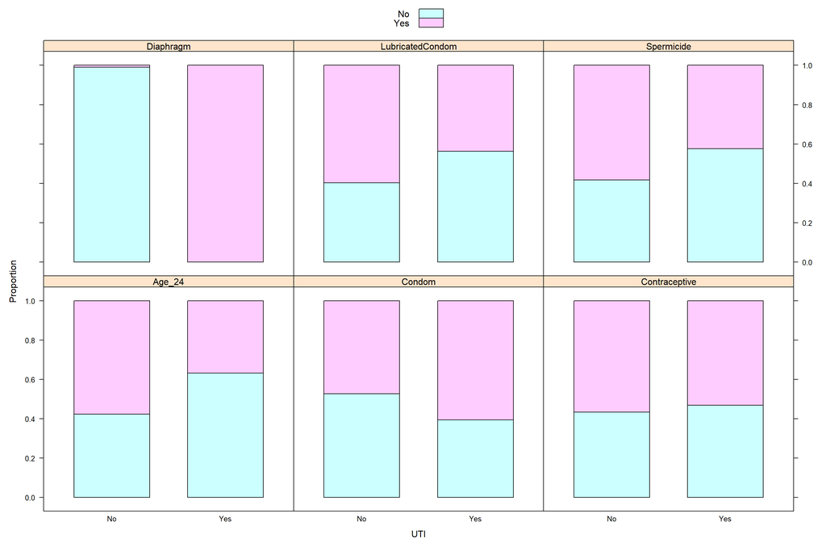

```r
##################################
# Restructuring the dataset for
# for barchart analysis
##################################
EDA.Bar.Source <- PMA_PreModelling_Train

##################################
# Creating a function to formulate
# the proportions table
##################################
EDA.PropTable.Function <- function(FactorVar) {
  EDA.Bar.Source.FactorVar <- EDA.Bar.Source[,c("UTI",
                                                FactorVar)]
  EDA.Bar.Source.FactorVar.Prop <- as.data.frame(prop.table(table(EDA.Bar.Source.FactorVar), 2))
  names(EDA.Bar.Source.FactorVar.Prop)[2] <- "UTI"
  EDA.Bar.Source.FactorVar.Prop$Variable <- rep(FactorVar,nrow(EDA.Bar.Source.FactorVar.Prop))

  return(EDA.Bar.Source.FactorVar.Prop)

}

EDA.Bar.Source.FactorVar.Prop <- rbind(EDA.PropTable.Function("Age_24"),
                                       EDA.PropTable.Function("Contraceptive"),
                                       EDA.PropTable.Function("Condom"),
                                       EDA.PropTable.Function("LubricatedCondom"),
                                       EDA.PropTable.Function("Spermicide"),
                                       EDA.PropTable.Function("Diaphragm"))

(EDA.Barchart.FactorVar <- barchart(EDA.Bar.Source.FactorVar.Prop[,3] ~
                                      EDA.Bar.Source.FactorVar.Prop[,2] | EDA.Bar.Source.FactorVar.Prop[,4],
                                      data=EDA.Bar.Source.FactorVar.Prop,
                                      groups = EDA.Bar.Source.FactorVar.Prop[,1],
                                      stack=TRUE,
                                      ylab = "Proportion",
                                      xlab = "UTI",
                                      auto.key = list(adj = 1),
                                      layout=(c(3,2))))
```

## 1.5 Predictive Model Index Development and Probability Curve Estimation

### 1.5.1 Logistic Regression (LR)

[Logistic Regression](http://dx.doi.org/10.2139/ssrn.360300) models the relationship between the probability of an event (among two outcome levels) by having the log-odds of the event be a linear combination of a set of predictors weighted by their respective parameter estimates. The parameters are estimated via maximum likelihood estimation by testing different values through multiple iterations to optimize for the best fit of log odds. All of these iterations produce the log likelihood function, and logistic regression seeks to maximize this function to find the best parameter estimates. Given the optimal parameters, the conditional probabilities for each observation can be calculated, logged, and summed together to yield a predicted probability.  
**[A]** The logistic regression model from the **stats** package was implemented. The UTI response was regressed against the Age_24, Contraceptive, Condom, LubricatedCondom, Spermicide and Diaphragm predictors.  
**[B]** The model does not contain any hyperparameter.  
**[C]** The model was not able to sufficiently compensate for the quasi-complete condition simulated for the Diaphragm predictor, resulting in the hyper-inflation of its estimated coefficients and standard errors.  
**[C.1]** Intercept coefficient = -2.868  
**[C.2]** Age_24 coefficient = -1.052  
**[C.3]** Contraceptive coefficient = -21.885  
**[C.4]** Condom coefficient = -22.120  
**[C.5]** LubricatedCondom coefficient = -1.687  
**[C.6]** Spermicide coefficient = +2.868  
**[C.7]** Diaphragm coefficient = +71.283  
**[D]** The logistic curve formulated by plotting the predicted probabilities against the classification index using the logit values showed a non-logistic profile with predicted points clustered in groups.  
**[E]** The performance of the model is summarized as follows:  
**[E.1]** Final model configuration is fixed due to the absence of a hyperparameter.  
**[E.2]** Apparent ROC Curve AUC = 0.99996  
**[E.3]** Estimated probabilities were practically dichotomized into a limited set of values.

**Code Chunk | Output**

```r
##################################
# Creating a local object
# for the train set
##################################
PMA_PreModelling_Train_LR <- UTI

##################################
# Formulating the structure of the
# Logistic Regression model
##################################
LR_Model <- glm(UTI ~ Age_24 + Contraceptive + Condom + LubricatedCondom + Spermicide + Diaphragm,
                data = PMA_PreModelling_Train_LR,
                family = binomial)

##################################
# Consolidating the model results
##################################
summary(LR_Model)
```

```
##
## Call:
## glm(formula = UTI ~ Age_24 + Contraceptive + Condom + LubricatedCondom +
##     Spermicide + Diaphragm, family = binomial, data = PMA_PreModelling_Train_LR)
##
## Deviance Residuals:
##      Min        1Q    Median        3Q       Max
## -1.17741  -0.00001   0.00000   0.00000   1.17741
##
## Coefficients:
##                   Estimate Std. Error z value Pr(>|z|)
## (Intercept)         -2.868  32506.120   0.000    1.000
## Age_24              -1.052  30909.202   0.000    1.000
## Contraceptive      -21.885  28411.225  -0.001    0.999
## Condom             -22.120  26985.686  -0.001    0.999
## LubricatedCondom    -1.687  25786.443   0.000    1.000
## Spermicide           2.868  32506.120   0.000    1.000
## Diaphragm           71.283  30516.786   0.002    0.998
##
## (Dispersion parameter for binomial family taken to be 1)
##
##     Null deviance: 329.4768  on 238  degrees of freedom
## Residual deviance:   2.7726  on 232  degrees of freedom
## AIC: 16.773
##
## Number of Fisher Scoring iterations: 24
```

```r
LR_Model_Coef <- (as.data.frame(LR_Model$coefficients))
LR_Model_Coef$Coef <- rownames(LR_Model_Coef)
LR_Model_Coef$Model <- rep("LR",nrow(LR_Model_Coef))
colnames(LR_Model_Coef) <- c("Estimates","Coefficients","Model")
print(LR_Model_Coef, rownames=FALSE)
```

```
##                   Estimates     Coefficients Model
## (Intercept)       -2.868285      (Intercept)    LR
## Age_24            -1.051834           Age_24    LR
## Contraceptive    -21.884704    Contraceptive    LR
## Condom           -22.119783           Condom    LR
## LubricatedCondom  -1.686565 LubricatedCondom    LR
## Spermicide         2.868285       Spermicide    LR
## Diaphragm         71.283177        Diaphragm    LR
```

```r
##################################
# Computing the model predictions
##################################
(LR_Model_Probabilities <- predict(LR_Model,
                              type = c("response")))
```

```
##            1            2            3            4            5            6
## 5.000000e-01 1.000000e+00 1.000000e+00 1.000000e+00 1.000000e+00 1.000000e+00
##            7            8            9           10           11           12
## 1.000000e+00 1.000000e+00 1.000000e+00 1.000000e+00 1.000000e+00 1.000000e+00
##           13           14           15           16           17           18
## 1.000000e+00 1.000000e+00 1.000000e+00 1.000000e+00 1.000000e+00 1.000000e+00
##           19           20           21           22           23           24
## 1.000000e+00 1.000000e+00 1.000000e+00 1.000000e+00 1.000000e+00 1.000000e+00
##           25           26           27           28           29           30
## 1.000000e+00 1.000000e+00 1.000000e+00 1.000000e+00 1.000000e+00 1.000000e+00
##           31           32           33           34           35           36
## 1.000000e+00 1.000000e+00 1.000000e+00 1.000000e+00 1.000000e+00 1.000000e+00
##           37           38           39           40           41           42
## 1.000000e+00 1.000000e+00 1.000000e+00 1.000000e+00 1.000000e+00 1.000000e+00
##           43           44           45           46           47           48
## 1.000000e+00 1.000000e+00 1.000000e+00 1.000000e+00 1.000000e+00 1.000000e+00
##           49           50           51           52           53           54
## 1.000000e+00 1.000000e+00 1.000000e+00 1.000000e+00 1.000000e+00 1.000000e+00
##           55           56           57           58           59           60
## 1.000000e+00 1.000000e+00 1.000000e+00 1.000000e+00 1.000000e+00 1.000000e+00
##           61           62           63           64           65           66
## 1.000000e+00 1.000000e+00 1.000000e+00 1.000000e+00 1.000000e+00 1.000000e+00
##           67           68           69           70           71           72
## 1.000000e+00 1.000000e+00 1.000000e+00 1.000000e+00 1.000000e+00 1.000000e+00
##           73           74           75           76           77           78
## 1.000000e+00 1.000000e+00 1.000000e+00 1.000000e+00 1.000000e+00 1.000000e+00
##           79           80           81           82           83           84
## 1.000000e+00 1.000000e+00 1.000000e+00 1.000000e+00 1.000000e+00 1.000000e+00
##           85           86           87           88           89           90
## 1.000000e+00 1.000000e+00 1.000000e+00 1.000000e+00 1.000000e+00 1.000000e+00
##           91           92           93           94           95           96
## 1.000000e+00 1.000000e+00 1.000000e+00 1.000000e+00 1.000000e+00 1.000000e+00
##           97           98           99          100          101          102
## 1.000000e+00 1.000000e+00 1.000000e+00 1.000000e+00 1.000000e+00 1.000000e+00
##          103          104          105          106          107          108
## 1.000000e+00 1.000000e+00 1.000000e+00 1.000000e+00 1.000000e+00 1.000000e+00
##          109          110          111          112          113          114
## 1.000000e+00 1.000000e+00 1.000000e+00 1.000000e+00 1.000000e+00 1.000000e+00
##          115          116          117          118          119          120
## 1.000000e+00 1.000000e+00 1.000000e+00 1.000000e+00 1.000000e+00 1.000000e+00
```

[output cut: 25 more lines]

```
## 1.777926e-11 1.777926e-11 1.777926e-11 1.777926e-11 1.777926e-11 1.777926e-11
##          199          200          201          202          203          204
## 1.777926e-11 1.777926e-11 1.777926e-11 1.777926e-11 3.130357e-10 2.220446e-16
##          205          206          207          208          209          210
## 2.220446e-16 2.220446e-16 2.220446e-16 2.220446e-16 2.220446e-16 2.220446e-16
##          211          212          213          214          215          216
## 2.220446e-16 2.220446e-16 2.220446e-16 2.220446e-16 2.220446e-16 9.089676e-13
##          217          218          219          220          221          222
## 9.089676e-13 1.600400e-11 1.600400e-11 1.600400e-11 1.600400e-11 6.210236e-12
##          223          224          225          226          227          228
## 6.210236e-12 6.210236e-12 6.210236e-12 6.210236e-12 6.210236e-12 6.210236e-12
##          229          230          231          232          233          234
## 6.210236e-12 6.210236e-12 6.210236e-12 6.210236e-12 6.210236e-12 6.210236e-12
##          235          236          237          238          239
## 6.210236e-12 1.093423e-10 2.220446e-16 2.220446e-16 2.220446e-16
```

```r
##################################
# Creating a classification index
# based from the model predictions
##################################
(LR_Model_Indices <- predict(LR_Model,
                           type = c("link")))
```

```
##             1             2             3             4             5
## -4.218847e-14  4.629511e+01  4.629511e+01  4.629511e+01  4.629511e+01
##             6             7             8             9            10
##  4.629511e+01  4.629511e+01  4.629511e+01  4.629511e+01  4.629511e+01
##            11            12            13            14            15
##  4.629511e+01  4.629511e+01  4.629511e+01  4.629511e+01  4.629511e+01
##            16            17            18            19            20
##  4.916339e+01  4.916339e+01  4.916339e+01  4.460854e+01  4.460854e+01
##            21            22            23            24            25
##  4.460854e+01  4.460854e+01  4.460854e+01  4.460854e+01  4.460854e+01
##            26            27            28            29            30
##  4.460854e+01  4.460854e+01  4.460854e+01  4.747683e+01  4.747683e+01
##            31            32            33            34            35
##  4.747683e+01  4.747683e+01  4.747683e+01  4.747683e+01  4.747683e+01
##            36            37            38            39            40
##  4.747683e+01  4.747683e+01  4.747683e+01  4.747683e+01  4.747683e+01
##            41            42            43            44            45
##  4.747683e+01  4.653019e+01  4.653019e+01  4.653019e+01  4.653019e+01
##            46            47            48            49            50
##  4.653019e+01  4.653019e+01  4.653019e+01  4.653019e+01  4.653019e+01
##            51            52            53            54            55
##  4.653019e+01  4.653019e+01  4.653019e+01  4.653019e+01  4.653019e+01
##            56            57            58            59            60
##  4.653019e+01  4.653019e+01  4.653019e+01  4.653019e+01  4.653019e+01
##            61            62            63            64            65
##  4.653019e+01  4.653019e+01  4.653019e+01  4.653019e+01  4.653019e+01
##            66            67            68            69            70
##  4.653019e+01  4.653019e+01  4.653019e+01  4.653019e+01  4.653019e+01
##            71            72            73            74            75
##  4.653019e+01  4.653019e+01  4.653019e+01  4.653019e+01  4.653019e+01
##            76            77            78            79            80
##  4.653019e+01  4.653019e+01  4.653019e+01  4.653019e+01  4.653019e+01
##            81            82            83            84            85
##  4.653019e+01  4.653019e+01  4.653019e+01  4.653019e+01  4.653019e+01
##            86            87            88            89            90
##  4.653019e+01  4.653019e+01  4.653019e+01  2.441040e+01  2.441040e+01
##            91            92            93            94            95
##  2.441040e+01  2.441040e+01  2.441040e+01  2.441040e+01  2.441040e+01
##            96            97            98            99           100
##  2.441040e+01  2.441040e+01  2.441040e+01  2.441040e+01  2.441040e+01
```

[output cut: 41 more lines]

```
## -2.475299e+01 -2.475299e+01 -2.188470e+01 -4.687277e+01 -4.855934e+01
##           206           207           208           209           210
## -4.855934e+01 -4.855934e+01 -4.855934e+01 -4.855934e+01 -4.569105e+01
##           211           212           213           214           215
## -4.569105e+01 -4.569105e+01 -4.569105e+01 -4.569105e+01 -4.569105e+01
##           216           217           218           219           220
## -2.772647e+01 -2.772647e+01 -2.485818e+01 -2.485818e+01 -2.485818e+01
##           221           222           223           224           225
## -2.485818e+01 -2.580482e+01 -2.580482e+01 -2.580482e+01 -2.580482e+01
##           226           227           228           229           230
## -2.580482e+01 -2.580482e+01 -2.580482e+01 -2.580482e+01 -2.580482e+01
##           231           232           233           234           235
## -2.580482e+01 -2.580482e+01 -2.580482e+01 -2.580482e+01 -2.580482e+01
##           236           237           238           239
## -2.293654e+01 -4.792461e+01 -4.674289e+01 -4.674289e+01
```

```r
max(LR_Model_Indices)
```

```
## [1] 49.16339
```

```r
min(LR_Model_Indices)
```

```
## [1] -48.55934
```

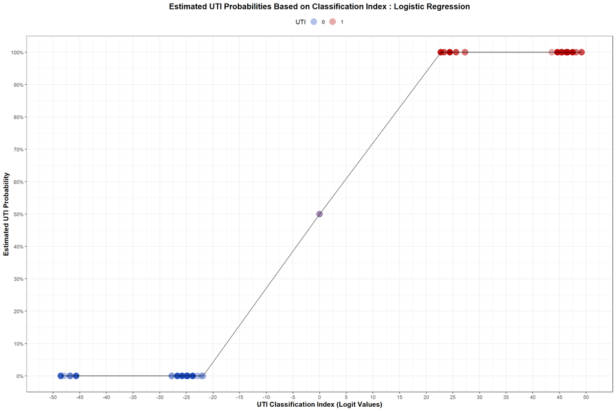

```r
##################################
# Consolidating the model probabilities
# and classification index
# based from the model predictions
##################################
LR_Model_Predictions <- as.data.frame(PMA_PreModelling_Train_LR)
LR_Model_Predictions$LR_Prob <- LR_Model_Probabilities
LR_Model_Predictions$LR_LP <- LR_Model_Indices
LR_Model_Predictions$UTI <- as.factor(LR_Model_Predictions$UTI)
LR_Model_Predictions$Label <- rep("LR",nrow(LR_Model_Predictions))

##################################
# Formulating the probability curve
# using the consolidated model predictions
##################################
LR_Model_Predictions %>%
  ggplot(aes(x = LR_LP ,
             y = LR_Prob,
             color = UTI)) +
  scale_colour_manual(values=c("#1846BA55","#B8000055")) +
  geom_point(size=5) +
  geom_line(color="black") +
  xlab("UTI Classification Index (Logit Values)") +
  ylab("Estimated UTI Probability") +
  labs(color = "UTI") +
  scale_x_continuous( limits=c(-50,50), breaks=seq(-50,50,by=5)) +
  scale_y_continuous( limits=c(0,1), breaks=seq(0,1,by=0.1),labels = scales::percent) +
  ggtitle("Estimated UTI Probabilities Based on Classification Index : Logistic Regression") +
  theme_bw() +
  theme(plot.title = element_text(color="black", size=14, face="bold", hjust=0.50),
        axis.title.x = element_text(color="black", size=12, face="bold"),
        axis.title.y = element_text(color="black", size=12, face="bold"),
        legend.position="top")
```

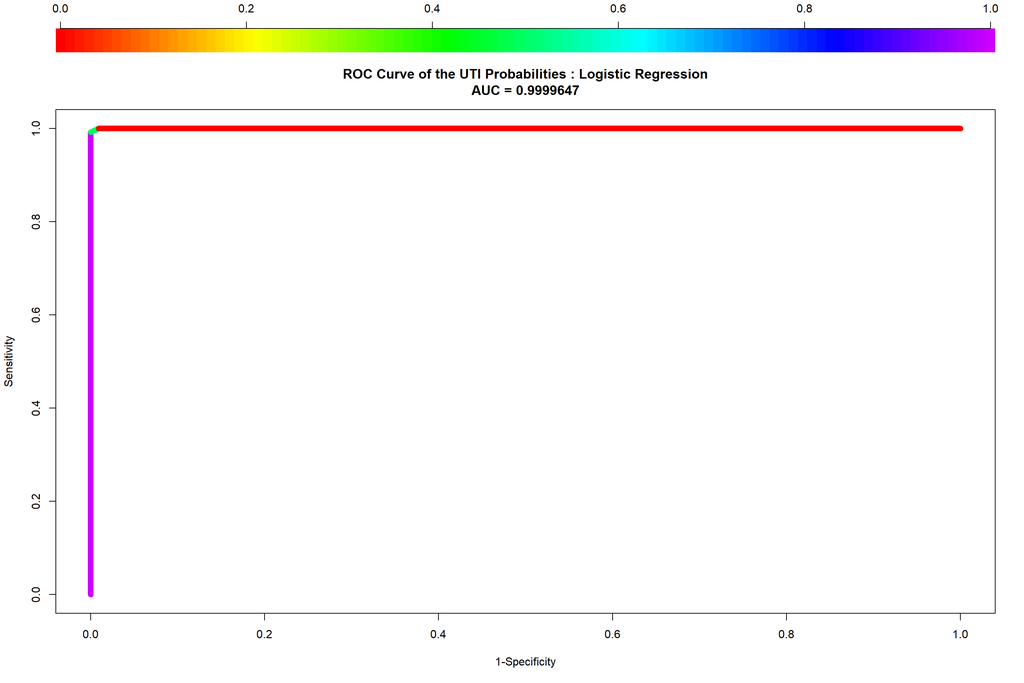

```r
##################################
# Formulating the corresponding
# receiver operating characteristic (ROC) curve
# using the model predictions
##################################
LR_Prob_Low  <- LR_Model_Predictions[LR_Model_Predictions$UTI==0,
                                    c("LR_Prob")]
LR_Prob_High <- LR_Model_Predictions[LR_Model_Predictions$UTI==1,
                                    c("LR_Prob")]
LR_Model_Prob_ROC <- roc.curve(scores.class1 = LR_Prob_Low,
                               scores.class0 = LR_Prob_High,
                                curve = TRUE)

plot(LR_Model_Prob_ROC,
     xlab="1-Specificity",
     ylab="Sensitivity",
     main="ROC Curve of the UTI Probabilities : Logistic Regression",
     color=TRUE,
     lwd=8,
     legend=3)
```